# Введение

В этом исследовании я выступаю в роли маректингового аналитика развлекательного приложения Procrastinate Pro+. Несмотря на огромные вложения в рекламу, последние несколько месяцев компания терпит убытки. Цель исследования — разобраться в истинных причинах убытков и помочь компании выйти в плюс. В моём распоряжении данные о пользователях, привлечённых с 1 мая по 27 октября 2019 года — этих данных должно хватить, чтобы сделать выводы.

# Шаг 1. Загрузка данных и их подготовка к анализу

```python
# импортируем нужные библиотеки

import pandas as pd
import seaborn as sns
from matplotlib import pyplot as plt
from datetime import timedelta, datetime
import numpy as np
import warnings
warnings.simplefilter("ignore")
```

```python
# считываем данные
try:
    visits = pd.read_csv('/datasets/visits_info_short.csv') # посещения
    orders = pd.read_csv('/datasets/orders_info_short.csv') # покупки
    costs = pd.read_csv('/datasets/costs_info_short.csv') # расходы на рекламу
except:
    visits = pd.read_csv('visits_info_short.csv') # посещения
    orders = pd.read_csv('orders_info_short.csv') # покупки
    costs = pd.read_csv('costs_info_short.csv') # расходы на рекламу
```

```python
# изучим данные в таблице visits

visits.info()
```

```
<class 'pandas.core.frame.DataFrame'>
RangeIndex: 309901 entries, 0 to 309900
Data columns (total 6 columns):
 #   Column         Non-Null Count   Dtype
---  ------         --------------   -----
 0   User Id        309901 non-null  int64
 1   Region         309901 non-null  object
 2   Device         309901 non-null  object
 3   Channel        309901 non-null  object
 4   Session Start  309901 non-null  object
 5   Session End    309901 non-null  object
dtypes: int64(1), object(5)
memory usage: 14.2+ MB
```

```python
# приведём имена столбцов в таблице visits к удобочитаемому виду

visits.columns = visits.columns.str.lower().str.replace(' ', '_')

# приведём тип данных в столбцах 'session_start' и 'session_end' к типу datetime

visits['session_start'], visits['session_end'] = (
    pd.to_datetime(visits['session_start']),
    pd.to_datetime(visits['session_end'])
)

# убедимся, что изменения вступили в силу
visits.info()
```

```
<class 'pandas.core.frame.DataFrame'>
RangeIndex: 309901 entries, 0 to 309900
Data columns (total 6 columns):
 #   Column         Non-Null Count   Dtype
---  ------         --------------   -----
 0   user_id        309901 non-null  int64
 1   region         309901 non-null  object
 2   device         309901 non-null  object
 3   channel        309901 non-null  object
 4   session_start  309901 non-null  datetime64[ns]
 5   session_end    309901 non-null  datetime64[ns]
dtypes: datetime64[ns](2), int64(1), object(3)
memory usage: 14.2+ MB
```

```python
# изучим данные в таблице orders

orders.info()
```

```
<class 'pandas.core.frame.DataFrame'>
RangeIndex: 40212 entries, 0 to 40211
Data columns (total 3 columns):
 #   Column    Non-Null Count  Dtype
---  ------    --------------  -----
 0   User Id   40212 non-null  int64
 1   Event Dt  40212 non-null  object
 2   Revenue   40212 non-null  float64
dtypes: float64(1), int64(1), object(1)
memory usage: 942.6+ KB
```

```python
# приведём имена столбцов в таблице orders к удобочитаемому виду

orders.columns = orders.columns.str.lower().str.replace(' ', '_')

orders['event_dt'] = pd.to_datetime(orders['event_dt'])

# убедимся, что изменения вступили в силу
orders.info()
```

```
<class 'pandas.core.frame.DataFrame'>
RangeIndex: 40212 entries, 0 to 40211
Data columns (total 3 columns):
 #   Column    Non-Null Count  Dtype
---  ------    --------------  -----
 0   user_id   40212 non-null  int64
 1   event_dt  40212 non-null  datetime64[ns]
 2   revenue   40212 non-null  float64
dtypes: datetime64[ns](1), float64(1), int64(1)
memory usage: 942.6 KB
```

```python
# изучим данные в таблице costs

costs.info()
```

```
<class 'pandas.core.frame.DataFrame'>
RangeIndex: 1800 entries, 0 to 1799
Data columns (total 3 columns):
 #   Column   Non-Null Count  Dtype
---  ------   --------------  -----
 0   dt       1800 non-null   object
 1   Channel  1800 non-null   object
 2   costs    1800 non-null   float64
dtypes: float64(1), object(2)
memory usage: 42.3+ KB
```

```python
costs.columns = costs.columns.str.lower().str.replace(' ', '_')
costs['month'] = pd.to_datetime(costs['dt']).dt.month # добавим в таблицу столбец с номером месяца
costs['dt'] = pd.to_datetime(costs['dt']).dt.date


costs.info()
```

```
<class 'pandas.core.frame.DataFrame'>
RangeIndex: 1800 entries, 0 to 1799
Data columns (total 4 columns):
 #   Column   Non-Null Count  Dtype
---  ------   --------------  -----
 0   dt       1800 non-null   object
 1   channel  1800 non-null   object
 2   costs    1800 non-null   float64
 3   month    1800 non-null   int64
dtypes: float64(1), int64(1), object(2)
memory usage: 56.4+ KB
```

```python
# ознакомимся с видом таблиц
display(visits.head())
display(orders.head())
display(costs.head())
```

|  | user_id | region | device | channel | session_start | session_end |
| --- | --- | --- | --- | --- | --- | --- |
| 0 | 981449118918 | United States | iPhone | organic | 2019-05-01 02:36:01 | 2019-05-01 02:45:01 |
| 1 | 278965908054 | United States | iPhone | organic | 2019-05-01 04:46:31 | 2019-05-01 04:47:35 |
| 2 | 590706206550 | United States | Mac | organic | 2019-05-01 14:09:25 | 2019-05-01 15:32:08 |
| 3 | 326433527971 | United States | Android | TipTop | 2019-05-01 00:29:59 | 2019-05-01 00:54:25 |
| 4 | 349773784594 | United States | Mac | organic | 2019-05-01 03:33:35 | 2019-05-01 03:57:40 |

|  | user_id | event_dt | revenue |
| --- | --- | --- | --- |
| 0 | 188246423999 | 2019-05-01 23:09:52 | 4.99 |
| 1 | 174361394180 | 2019-05-01 12:24:04 | 4.99 |
| 2 | 529610067795 | 2019-05-01 11:34:04 | 4.99 |
| 3 | 319939546352 | 2019-05-01 15:34:40 | 4.99 |
| 4 | 366000285810 | 2019-05-01 13:59:51 | 4.99 |

|  | dt | channel | costs | month |
| --- | --- | --- | --- | --- |
| 0 | 2019-05-01 | FaceBoom | 113.3 | 5 |
| 1 | 2019-05-02 | FaceBoom | 78.1 | 5 |
| 2 | 2019-05-03 | FaceBoom | 85.8 | 5 |
| 3 | 2019-05-04 | FaceBoom | 136.4 | 5 |
| 4 | 2019-05-05 | FaceBoom | 122.1 | 5 |

```python
# Проверяем таблицу visits на наличие грубых дубликатов
visits.duplicated().sum()
```

```
0
```

```python
# Проверяем таблицу visits на наличие пропусков
visits.isnull().sum()
```

```
user_id          0
region           0
device           0
channel          0
session_start    0
session_end      0
dtype: int64
```

```python
# Проверяем таблицу orders на наличие грубых дубликатов
orders.duplicated().sum()
```

```
0
```

```python
# Проверяем таблицу orders на наличие пропусков
orders.isnull().sum()
```

```
user_id     0
event_dt    0
revenue     0
dtype: int64
```

```python
# Проверяем таблицу costs на наличие грубых дубликатов
costs.duplicated().sum()
```

```
0
```

```python
# Проверяем таблицу costs на наличие пропусков
costs.isnull().sum()
```

```
dt         0
channel    0
costs      0
month      0
dtype: int64
```

В результате предобработки данных мы привели названия столбцов к нижнему регистру, заменили в них символы пробелов на символы нижнего подчёркивания и убедились в том, что данные не содержат грубых дубликатов и пропусков во всех трёх таблицах. Это хороший знак, можно говорить о том, что качество данных находится на высоком уровне.

# Шаг 2. Задаём функции для расчета и анализа LTV, ROI, удержания и конверсии

Разрешается использовать функции, с которыми вы познакомились в теоретических уроках.

```python
# функция для создания пользовательских профилей

def get_profiles(sessions, orders, ad_costs):

    # находим параметры первых посещений
    profiles = (
        sessions.sort_values(by=['user_id', 'session_start'])
        .groupby('user_id')
        .agg(
            {
                'session_start': 'first',
                'channel': 'first',
                'device': 'first',
                'region': 'first',
            }
        )
        .rename(columns={'session_start': 'first_ts'})
        .reset_index()
    )

    # для когортного анализа определяем дату первого посещения
    # и первый день месяца, в который это посещение произошло
    profiles['dt'] = profiles['first_ts'].dt.date
    profiles['month'] = profiles['first_ts'].astype('datetime64[M]')

    # добавляем признак платящих пользователей
    profiles['payer'] = profiles['user_id'].isin(orders['user_id'].unique())


    # считаем количество уникальных пользователей
    # с одинаковыми источником и датой привлечения
    new_users = (
        profiles.groupby(['dt', 'channel'])
        .agg({'user_id': 'nunique'})
        .rename(columns={'user_id': 'unique_users'})
        .reset_index()
    )

    # объединяем траты на рекламу и число привлечённых пользователей
    ad_costs = ad_costs.merge(new_users, on=['dt', 'channel'], how='left')

    # делим рекламные расходы на число привлечённых пользователей
    ad_costs['acquisition_cost'] = ad_costs['costs'] / ad_costs['unique_users']

    # добавляем стоимость привлечения в профили
    profiles = profiles.merge(
        ad_costs[['dt', 'channel', 'acquisition_cost']],
        on=['dt', 'channel'],
        how='left',
    )

    # стоимость привлечения органических пользователей равна нулю
    profiles['acquisition_cost'] = profiles['acquisition_cost'].fillna(0)

    return profiles
```

```python
# функция для расчёта удержания

def get_retention(
    profiles,
    sessions,
    observation_date,
    horizon_days,
    dimensions=[],
    ignore_horizon=False,
):

    # добавляем столбец payer в передаваемый dimensions список
    dimensions = ['payer'] + dimensions

    # исключаем пользователей, не «доживших» до горизонта анализа
    last_suitable_acquisition_date = observation_date
    if not ignore_horizon:
        last_suitable_acquisition_date = observation_date - timedelta(
            days=horizon_days - 1
        )
    result_raw = profiles.query('dt <= @last_suitable_acquisition_date')

    # собираем «сырые» данные для расчёта удержания
    result_raw = result_raw.merge(
        sessions[['user_id', 'session_start']], on='user_id', how='left'
    )
    result_raw['lifetime'] = (
        result_raw['session_start'] - result_raw['first_ts']
    ).dt.days

    # функция для группировки таблицы по желаемым признакам
    def group_by_dimensions(df, dims, horizon_days):
        result = df.pivot_table(
            index=dims, columns='lifetime', values='user_id', aggfunc='nunique'
        )
        cohort_sizes = (
            df.groupby(dims)
            .agg({'user_id': 'nunique'})
            .rename(columns={'user_id': 'cohort_size'})
        )
        result = cohort_sizes.merge(result, on=dims, how='left').fillna(0)
        result = result.div(result['cohort_size'], axis=0)
        result = result[['cohort_size'] + list(range(horizon_days))]
        result['cohort_size'] = cohort_sizes
        return result

    # получаем таблицу удержания
    result_grouped = group_by_dimensions(result_raw, dimensions, horizon_days)

    # получаем таблицу динамики удержания
    result_in_time = group_by_dimensions(
        result_raw, dimensions + ['dt'], horizon_days
    )

    # возвращаем обе таблицы и сырые данные
    return result_raw, result_grouped, result_in_time
```

```python
# функция для расчёта конверсии

def get_conversion(
    profiles,
    purchases,
    observation_date,
    horizon_days,
    dimensions=[],
    ignore_horizon=False,
):

    # исключаем пользователей, не «доживших» до горизонта анализа
    last_suitable_acquisition_date = observation_date
    if not ignore_horizon:
        last_suitable_acquisition_date = observation_date - timedelta(
            days=horizon_days - 1
        )
    result_raw = profiles.query('dt <= @last_suitable_acquisition_date')

    # определяем дату и время первой покупки для каждого пользователя
    first_purchases = (
        purchases.sort_values(by=['user_id', 'event_dt'])
        .groupby('user_id')
        .agg({'event_dt': 'first'})
        .reset_index()
    )

    # добавляем данные о покупках в профили
    result_raw = result_raw.merge(
        first_purchases[['user_id', 'event_dt']], on='user_id', how='left'
    )

    # рассчитываем лайфтайм для каждой покупки
    result_raw['lifetime'] = (
        result_raw['event_dt'] - result_raw['first_ts']
    ).dt.days

    # группируем по cohort, если в dimensions ничего нет
    if len(dimensions) == 0:
        result_raw['cohort'] = 'All users'
        dimensions = dimensions + ['cohort']

    # функция для группировки таблицы по желаемым признакам
    def group_by_dimensions(df, dims, horizon_days):
        result = df.pivot_table(
            index=dims, columns='lifetime', values='user_id', aggfunc='nunique'
        )
        result = result.fillna(0).cumsum(axis = 1)
        cohort_sizes = (
            df.groupby(dims)
            .agg({'user_id': 'nunique'})
            .rename(columns={'user_id': 'cohort_size'})
        )
        result = cohort_sizes.merge(result, on=dims, how='left').fillna(0)
        # делим каждую «ячейку» в строке на размер когорты
        # и получаем conversion rate
        result = result.div(result['cohort_size'], axis=0)
        result = result[['cohort_size'] + list(range(horizon_days))]
        result['cohort_size'] = cohort_sizes
        return result

    # получаем таблицу конверсии
    result_grouped = group_by_dimensions(result_raw, dimensions, horizon_days)

    # для таблицы динамики конверсии убираем 'cohort' из dimensions
    if 'cohort' in dimensions:
        dimensions = []

    # получаем таблицу динамики конверсии
    result_in_time = group_by_dimensions(
        result_raw, dimensions + ['dt'], horizon_days
    )

    # возвращаем обе таблицы и сырые данные
    return result_raw, result_grouped, result_in_time
```

```python
# функция для расчёта LTV и ROI

def get_ltv(
    profiles,
    purchases,
    observation_date,
    horizon_days,
    dimensions=[],
    ignore_horizon=False,
):

    # исключаем пользователей, не «доживших» до горизонта анализа
    last_suitable_acquisition_date = observation_date
    if not ignore_horizon:
        last_suitable_acquisition_date = observation_date - timedelta(
            days=horizon_days - 1
        )
    result_raw = profiles.query('dt <= @last_suitable_acquisition_date')
    # добавляем данные о покупках в профили
    result_raw = result_raw.merge(
        purchases[['user_id', 'event_dt', 'revenue']], on='user_id', how='left'
    )
    # рассчитываем лайфтайм пользователя для каждой покупки
    result_raw['lifetime'] = (
        result_raw['event_dt'] - result_raw['first_ts']
    ).dt.days
    # группируем по cohort, если в dimensions ничего нет
    if len(dimensions) == 0:
        result_raw['cohort'] = 'All users'
        dimensions = dimensions + ['cohort']

    # функция группировки по желаемым признакам
    def group_by_dimensions(df, dims, horizon_days):
        # строим «треугольную» таблицу выручки
        result = df.pivot_table(
            index=dims, columns='lifetime', values='revenue', aggfunc='sum'
        )
        # находим сумму выручки с накоплением
        result = result.fillna(0).cumsum(axis=1)
        # вычисляем размеры когорт
        cohort_sizes = (
            df.groupby(dims)
            .agg({'user_id': 'nunique'})
            .rename(columns={'user_id': 'cohort_size'})
        )
        # объединяем размеры когорт и таблицу выручки
        result = cohort_sizes.merge(result, on=dims, how='left').fillna(0)
        # считаем LTV: делим каждую «ячейку» в строке на размер когорты
        result = result.div(result['cohort_size'], axis=0)
        # исключаем все лайфтаймы, превышающие горизонт анализа
        result = result[['cohort_size'] + list(range(horizon_days))]
        # восстанавливаем размеры когорт
        result['cohort_size'] = cohort_sizes

        # собираем датафрейм с данными пользователей и значениями CAC,
        # добавляя параметры из dimensions
        cac = df[['user_id', 'acquisition_cost'] + dims].drop_duplicates()

        # считаем средний CAC по параметрам из dimensions
        cac = (
            cac.groupby(dims)
            .agg({'acquisition_cost': 'mean'})
            .rename(columns={'acquisition_cost': 'cac'})
        )

        # считаем ROI: делим LTV на CAC
        roi = result.div(cac['cac'], axis=0)

        # удаляем строки с бесконечным ROI
        roi = roi[~roi['cohort_size'].isin([np.inf])]

        # восстанавливаем размеры когорт в таблице ROI
        roi['cohort_size'] = cohort_sizes

        # добавляем CAC в таблицу ROI
        roi['cac'] = cac['cac']

        # в финальной таблице оставляем размеры когорт, CAC
        # и ROI в лайфтаймы, не превышающие горизонт анализа
        roi = roi[['cohort_size', 'cac'] + list(range(horizon_days))]

        # возвращаем таблицы LTV и ROI
        return result, roi

    # получаем таблицы LTV и ROI
    result_grouped, roi_grouped = group_by_dimensions(
        result_raw, dimensions, horizon_days
    )

    # для таблиц динамики убираем 'cohort' из dimensions
    if 'cohort' in dimensions:
        dimensions = []

    # получаем таблицы динамики LTV и ROI
    result_in_time, roi_in_time = group_by_dimensions(
        result_raw, dimensions + ['dt'], horizon_days
    )

    return (
        result_raw,  # сырые данные
        result_grouped,  # таблица LTV
        result_in_time,  # таблица динамики LTV
        roi_grouped,  # таблица ROI
        roi_in_time,  # таблица динамики ROI
    )
```

```python
# функция для сглаживания фрейма

def filter_data(df, window):
    # для каждого столбца применяем скользящее среднее
    for column in df.columns.values:
        df[column] = df[column].rolling(window).mean()
    return df
```

```python
# функция для визуализации удержания

def plot_retention(retention, retention_history, horizon, window=7):

    # задаём размер сетки для графиков
    plt.figure(figsize=(15, 10))

    # исключаем размеры когорт и удержание первого дня
    retention = retention.drop(columns=['cohort_size', 0])
    # в таблице динамики оставляем только нужный лайфтайм
    retention_history = retention_history.drop(columns=['cohort_size'])[
        [horizon - 1]
    ]

    # если в индексах таблицы удержания только payer,
    # добавляем второй признак — cohort
    if retention.index.nlevels == 1:
        retention['cohort'] = 'All users'
        retention = retention.reset_index().set_index(['cohort', 'payer'])

    # в таблице графиков — два столбца и две строки, четыре ячейки
    # в первой строим кривые удержания платящих пользователей
    ax1 = plt.subplot(2, 2, 1)
    retention.query('payer == True').droplevel('payer').T.plot(
        grid=True, ax=ax1
    )
    plt.legend()
    plt.xlabel('Лайфтайм')
    plt.title('Удержание платящих пользователей')

    # во второй ячейке строим кривые удержания неплатящих
    # вертикальная ось — от графика из первой ячейки
    ax2 = plt.subplot(2, 2, 2, sharey=ax1)
    retention.query('payer == False').droplevel('payer').T.plot(
        grid=True, ax=ax2
    )
    plt.legend()
    plt.xlabel('Лайфтайм')
    plt.title('Удержание неплатящих пользователей')

    # в третьей ячейке — динамика удержания платящих
    ax3 = plt.subplot(2, 2, 3)
    # получаем названия столбцов для сводной таблицы
    columns = [
        name
        for name in retention_history.index.names
        if name not in ['dt', 'payer']
    ]
    # фильтруем данные и строим график
    filtered_data = retention_history.query('payer == True').pivot_table(
        index='dt', columns=columns, values=horizon - 1, aggfunc='mean'
    )
    filter_data(filtered_data, window).plot(grid=True, ax=ax3)
    plt.xlabel('Дата привлечения')
    plt.title(
        'Динамика удержания платящих пользователей на {}-й день'.format(
            horizon
        )
    )

    # в чётвертой ячейке — динамика удержания неплатящих
    ax4 = plt.subplot(2, 2, 4, sharey=ax3)
    # фильтруем данные и строим график
    filtered_data = retention_history.query('payer == False').pivot_table(
        index='dt', columns=columns, values=horizon - 1, aggfunc='mean'
    )
    filter_data(filtered_data, window).plot(grid=True, ax=ax4)
    plt.xlabel('Дата привлечения')
    plt.title(
        'Динамика удержания неплатящих пользователей на {}-й день'.format(
            horizon
        )
    )

    plt.tight_layout()
    plt.show()
```

```python
# функция для визуализации конверсии

def plot_conversion(conversion, conversion_history, horizon, window=7):

    # задаём размер сетки для графиков
    plt.figure(figsize=(15, 5))

    # исключаем размеры когорт
    conversion = conversion.drop(columns=['cohort_size'])
    # в таблице динамики оставляем только нужный лайфтайм
    conversion_history = conversion_history.drop(columns=['cohort_size'])[
        [horizon - 1]
    ]

    # первый график — кривые конверсии
    ax1 = plt.subplot(1, 2, 1)
    conversion.T.plot(grid=True, ax=ax1)
    plt.legend()
    plt.xlabel('Лайфтайм')
    plt.title('Конверсия пользователей')

    # второй график — динамика конверсии
    ax2 = plt.subplot(1, 2, 2, sharey=ax1)
    columns = [
        # столбцами сводной таблицы станут все столбцы индекса, кроме даты
        name for name in conversion_history.index.names if name not in ['dt']
    ]
    filtered_data = conversion_history.pivot_table(
        index='dt', columns=columns, values=horizon - 1, aggfunc='mean'
    )
    filter_data(filtered_data, window).plot(grid=True, ax=ax2)
    plt.xlabel('Дата привлечения')
    plt.title('Динамика конверсии пользователей на {}-й день'.format(horizon))

    plt.tight_layout()
    plt.show()
```

```python
# функция для визуализации LTV и ROI

def plot_ltv_roi(ltv, ltv_history, roi, roi_history, horizon, window=7):

    # задаём сетку отрисовки графиков
    plt.figure(figsize=(20, 10))

    # из таблицы ltv исключаем размеры когорт
    ltv = ltv.drop(columns=['cohort_size'])
    # в таблице динамики ltv оставляем только нужный лайфтайм
    ltv_history = ltv_history.drop(columns=['cohort_size'])[[horizon - 1]]

    # стоимость привлечения запишем в отдельный фрейм
    cac_history = roi_history[['cac']]

    # из таблицы roi исключаем размеры когорт и cac
    roi = roi.drop(columns=['cohort_size', 'cac'])
    # в таблице динамики roi оставляем только нужный лайфтайм
    roi_history = roi_history.drop(columns=['cohort_size', 'cac'])[
        [horizon - 1]
    ]

    # первый график — кривые ltv
    ax1 = plt.subplot(2, 3, 1)
    ltv.T.plot(grid=True, ax=ax1)
    plt.legend()
    plt.xlabel('Лайфтайм')
    plt.title('LTV')

    # второй график — динамика ltv
    ax2 = plt.subplot(2, 3, 2, sharey=ax1)
    # столбцами сводной таблицы станут все столбцы индекса, кроме даты
    columns = [name for name in ltv_history.index.names if name not in ['dt']]
    filtered_data = ltv_history.pivot_table(
        index='dt', columns=columns, values=horizon - 1, aggfunc='mean'
    )
    filter_data(filtered_data, window).plot(grid=True, ax=ax2)
    plt.xlabel('Дата привлечения')
    plt.title('Динамика LTV пользователей на {}-й день'.format(horizon))

    # третий график — динамика cac
    ax3 = plt.subplot(2, 3, 3, sharey=ax1)
    # столбцами сводной таблицы станут все столбцы индекса, кроме даты
    columns = [name for name in cac_history.index.names if name not in ['dt']]
    filtered_data = cac_history.pivot_table(
        index='dt', columns=columns, values='cac', aggfunc='mean'
    )
    filter_data(filtered_data, window).plot(grid=True, ax=ax3)
    plt.xlabel('Дата привлечения')
    plt.title('Динамика стоимости привлечения пользователей')

    # четвёртый график — кривые roi
    ax4 = plt.subplot(2, 3, 4)
    roi.T.plot(grid=True, ax=ax4)
    plt.axhline(y=1, color='red', linestyle='--', label='Уровень окупаемости')
    plt.legend()
    plt.xlabel('Лайфтайм')
    plt.title('ROI')

    # пятый график — динамика roi
    ax5 = plt.subplot(2, 3, 5, sharey=ax4)
    # столбцами сводной таблицы станут все столбцы индекса, кроме даты
    columns = [name for name in roi_history.index.names if name not in ['dt']]
    filtered_data = roi_history.pivot_table(
        index='dt', columns=columns, values=horizon - 1, aggfunc='mean'
    )
    filter_data(filtered_data, window).plot(grid=True, ax=ax5)
    plt.axhline(y=1, color='red', linestyle='--', label='Уровень окупаемости')
    plt.xlabel('Дата привлечения')
    plt.title('Динамика ROI пользователей на {}-й день'.format(horizon))

    plt.tight_layout()
    plt.show()
```

# Шаг 3. Проводим исследовательский анализ данных

Построим профили пользователей. Определим минимальную и максимальную дату привлечения пользователей.

Выясним:

- Из каких стран приходят посетители? Какие страны дают больше всего платящих пользователей?
- Какими устройствами они пользуются? С каких устройств чаще всего заходят платящие пользователи?
- По каким рекламным каналам шло привлечение пользователей? Какие каналы приносят больше всего платящих пользователей?

```python
# Получаем профили пользователей

profiles = get_profiles(visits, orders, costs)

# Ознакомимся со структурой таблицы
display(profiles.head(5))
```

|  | user_id | first_ts | channel | device | region | dt | month | payer | acquisition_cost |
| --- | --- | --- | --- | --- | --- | --- | --- | --- | --- |
| 0 | 599326 | 2019-05-07 20:58:57 | FaceBoom | Mac | United States | 2019-05-07 | 2019-05-01 | True | 1.088172 |
| 1 | 4919697 | 2019-07-09 12:46:07 | FaceBoom | iPhone | United States | 2019-07-09 | 2019-07-01 | False | 1.107237 |
| 2 | 6085896 | 2019-10-01 09:58:33 | organic | iPhone | France | 2019-10-01 | 2019-10-01 | False | 0.000000 |
| 3 | 22593348 | 2019-08-22 21:35:48 | AdNonSense | PC | Germany | 2019-08-22 | 2019-08-01 | False | 0.988235 |
| 4 | 31989216 | 2019-10-02 00:07:44 | YRabbit | iPhone | United States | 2019-10-02 | 2019-10-01 | False | 0.230769 |

```python
# Определим минимальную и максимальную дату привлечения пользователей

min_date = profiles['first_ts'].min()
max_date = profiles['first_ts'].max()
```

```python
print(f'Минимальная дата привлечения пользователей развлекательного приложения "Procrastinate Pro+": {min_date}')
print(f'Максимальная дата привлечения пользователей развлекательного приложения "Procrastinate Pro+": {max_date}')
```

```
Минимальная дата привлечения пользователей развлекательного приложения "Procrastinate Pro+": 2019-05-01 00:00:41
Максимальная дата привлечения пользователей развлекательного приложения "Procrastinate Pro+": 2019-10-27 23:59:04
```

Пользователи развлекательного приложения "Procrastinate Pro+" были привлечены в период с 1 мая по 27 октября 2019 года. Эти даты полностью соответствуют ТЗ.

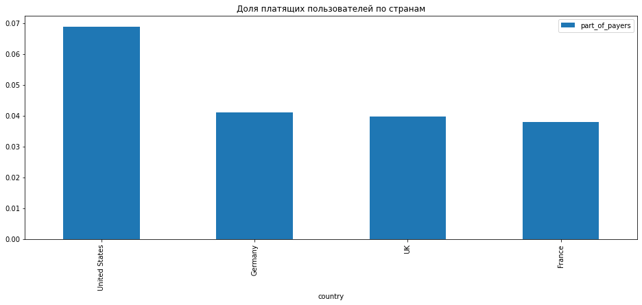

```python
# выясним, из каких стран приходят посетители и какие страны дают больше всего платящих пользователей

profiles.groupby('region').agg({'payer':'mean'}).rename(
    columns={
        'payer':'part_of_payers'
    }
).sort_values(by='part_of_payers', ascending=False).plot(
    kind='bar',
    figsize=(16, 6),
    xlabel='country',
    title='Доля платящих пользователей по странам'
)
```

| region | total_of_payers |
| --- | --- |
| United States | 6902 |
| UK | 700 |
| France | 663 |
| Germany | 616 |

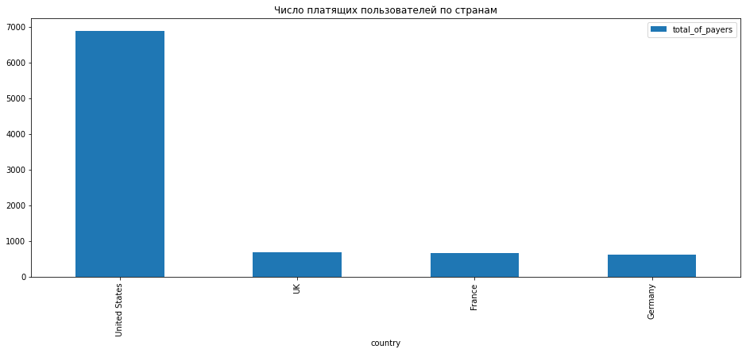

```python
# Обратим внимание на количество платящих пользователей в этих странах

payers_total_in_countries = profiles.query('payer == True').groupby('region').agg({'user_id':'count'}).rename(
    columns={
        'user_id':'total_of_payers'
    }
).sort_values(by='total_of_payers', ascending=False)

payers_total_in_countries.plot(
    kind='bar',
    figsize=(16, 6),
    xlabel='country',
    title='Число платящих пользователей по странам'
)

payers_total_in_countries
```

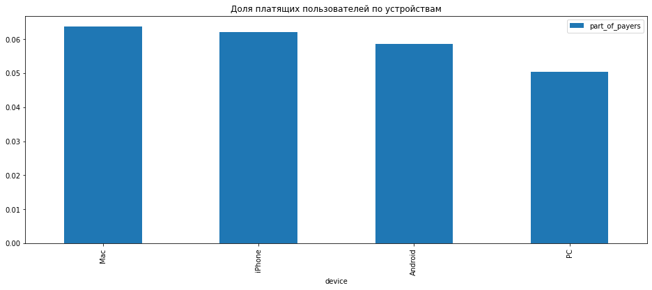

```python
profiles.groupby('device').agg({'payer':'mean'}).rename(
    columns={
        'payer':'part_of_payers'
    }
).sort_values(by='part_of_payers', ascending=False).plot(
    kind='bar',
    figsize=(16, 6),
    xlabel='device',
    title='Доля платящих пользователей по устройствам'
)
```

| device | total_of_payers |
| --- | --- |
| iPhone | 3382 |
| Android | 2050 |
| Mac | 1912 |
| PC | 1537 |

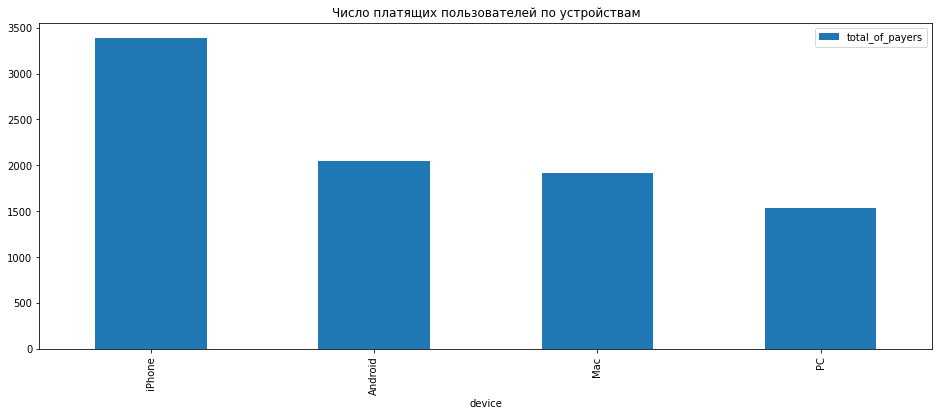

```python
payers_total_in_devices = profiles.query('payer == True').groupby('device').agg({'user_id':'count'}).rename(
    columns={
        'user_id':'total_of_payers'
    }
).sort_values(by='total_of_payers', ascending=False)

payers_total_in_devices.plot(
    kind='bar',
    figsize=(16, 6),
    xlabel='device',
    title='Число платящих пользователей по устройствам'
)

payers_total_in_devices
```

Пользователи развлекательного приложения «Procrastinate Pro+» используют устройства Iphone, Mac, Android и PC. Доля платящих пользователей выше среди владельцев Mac, а чаще всего платящие пользователи заходят с устройства Iphone: почти 3500 платящих клиентов являются обладателями этого девайса. Реже всего платят владельцы PC.

Теперь обратим внимание на то, по каким рекламным каналам шло привлечение пользователей и выясним, какие каналы приносят больше всего платящих пользователей.

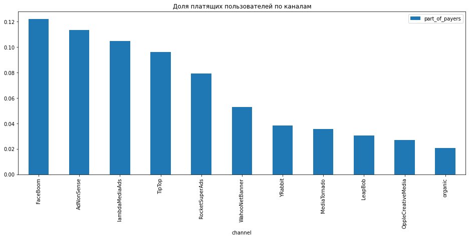

```python
profiles.groupby('channel').agg({'payer':'mean'}).rename(
    columns={
        'payer':'part_of_payers'
    }
).sort_values(by='part_of_payers', ascending=False).plot(
    kind='bar',
    figsize=(16, 6),
    xlabel='channel',
    title='Доля платящих пользователей по каналам'
)
```

| channel | total_of_payers |
| --- | --- |
| FaceBoom | 3557 |
| TipTop | 1878 |
| organic | 1160 |
| WahooNetBanner | 453 |
| AdNonSense | 440 |
| RocketSuperAds | 352 |
| LeapBob | 262 |
| OppleCreativeMedia | 233 |
| lambdaMediaAds | 225 |
| YRabbit | 165 |
| MediaTornado | 156 |

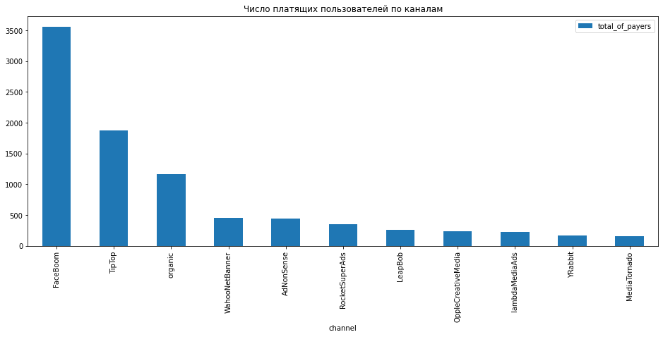

```python
payers_total_in_channels = profiles.query('payer == True').groupby('channel').agg({'user_id':'count'}).rename(
    columns={
        'user_id':'total_of_payers'
    }
).sort_values(by='total_of_payers', ascending=False)

payers_total_in_channels.plot(
    kind='bar',
    figsize=(16, 6),
    xlabel='channel',
    title='Число платящих пользователей по каналам'
)

payers_total_in_channels
```

Привлечение клиентов происходило через следующие каналы: FaceBoom, TipTop, organic, WahooNetBanner, AdNonSense, RocketSuperAds, LeapBob, OppleCreativeMedia, lambdaMediaAds, YRabbit и MediaTornado. Больше всего платящих клиентов привёл источник FaceBoom: примерно 12% приведённых пользователей стали платящими — это более чем 3500 человек.

# Промежуточный вывод третьего шага:

Мы имеем дело с данными, которые содержат пользователей, привлечённых в период с 1 мая по 27 октября 2019 года. Эти пользователи проживают в четырёх странах: США, Великобритания, Франция и Германия. Абсолютном лидером по числу и доле платящих пользователей является США: это почти 7000 клиентов. Клиенты используют устройства Mac, Iphone, Android и PC. Чаще всего платящие пользователи заходят с устройства Iphone: почти 3500 платящих клиентов являются обладателями этого девайса. Больше всего платящих клиентов привёл источник FaceBoom: примерно 12% приведённых им пользователей стали платящими — это более чем 3500 человек.

# Шаг 4. Маркетинг

Выясним:

- Сколько денег потратили? Всего / на каждый источник / по времени
- Сколько в среднем стоило привлечение одного покупателя из каждого источника?

```python
# Выясним, сколько денег было потрачено всего на привлечение пользователей

total_ac_cost = round(profiles['acquisition_cost'].sum(), 2)

print(f'Общая сумма расходов на маркетинг составила {total_ac_cost} $')
```

```
Общая сумма расходов на маркетинг составила 105497.3 $
```

| channel | acquisition_cost |
| --- | --- |
| TipTop | 54751.30 |
| FaceBoom | 32445.60 |
| WahooNetBanner | 5151.00 |
| AdNonSense | 3911.25 |
| OppleCreativeMedia | 2151.25 |
| RocketSuperAds | 1833.00 |
| LeapBob | 1797.60 |
| lambdaMediaAds | 1557.60 |
| MediaTornado | 954.48 |
| YRabbit | 944.22 |

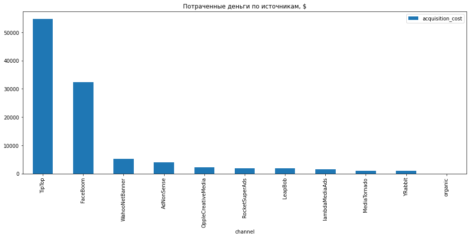

```python
# Оценим потраченные деньги в разрезе источников привлечения пользователей

costs_to_channels = profiles.groupby('channel').agg(
    {
        'acquisition_cost':'sum'
    }
).sort_values('acquisition_cost', ascending=False)

costs_to_channels.plot(
    kind='bar',
    figsize=(16, 6),
    title='Потраченные деньги по источникам, $',
)

display(costs_to_channels[:-1]) # выведем значения без канала Organic — Organic всегда приходит бесплатно
```

Больше всего средств из рекламного бюджета было потрачено на канал TipTop (54751.3), на втором месте — канал FaceBoom (32445.6) и тройку лидеров, пусть со значительным отрывом от первых двух мест, замыкает канал WahooNetBanner (5151). Из канала Organic пользователи приходили бесплатно, чего и следовало ожидать. Теперь оценим динамику расходов на привлечение пользователей

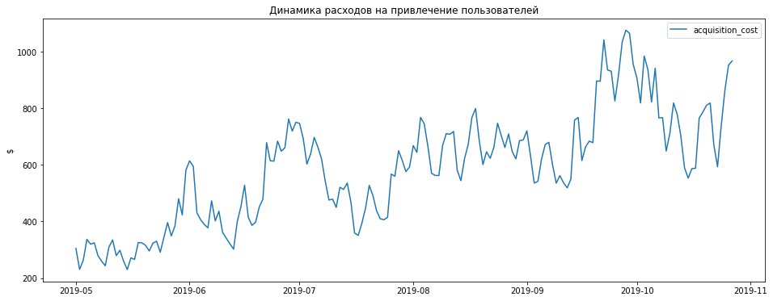

```python
costs_in_time = profiles.groupby('dt').agg({'acquisition_cost':'sum'})

costs_in_time.plot(figsize=(16, 6), title='Динамика расходов на привлечение пользователей', ylabel='$', xlabel='')
```

По графику динамики расходов на привлечение пользователей можно сделать вывод о том, что расходы с течением времени росли: на графике можно проследить явный тренд в направлении увеличения суммы расходов. Теперь узнаем, сколько в среднем стоило привлечение одного пользователя из каждого источника.

```python
# Избавимся от канала Organic в профилях

non_organic_profiles = profiles.query('channel != "organic"')
```

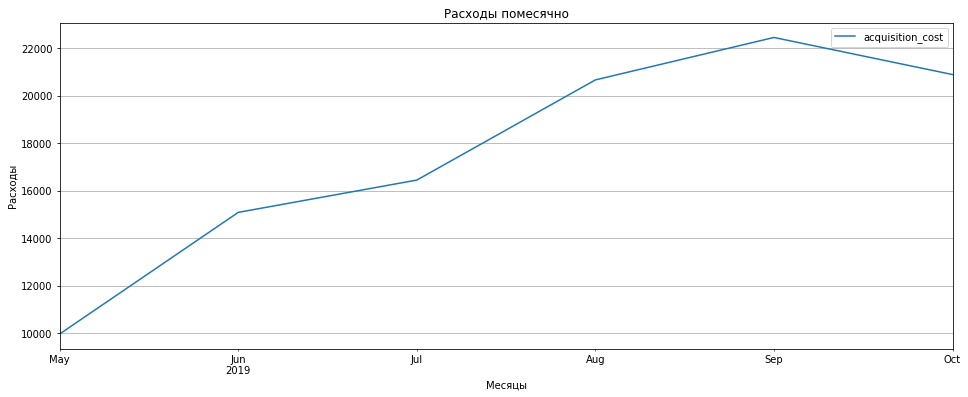

```python
# Строим график расходов по месяцам

сosts_in_months = non_organic_profiles.groupby('month').agg({'acquisition_cost':'sum'})

сosts_in_months.plot(figsize=(16, 6), title='Расходы помесячно', ylabel='Расходы', xlabel='Месяцы', grid=True)
```

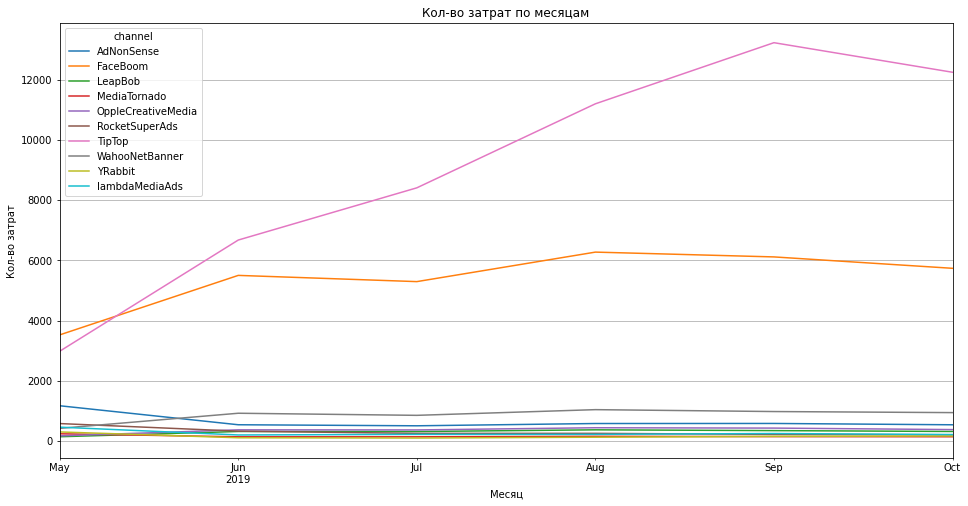

```python
monthly_costs_in_channels = non_organic_profiles.pivot_table(
    index='month', columns='channel', values='acquisition_cost', aggfunc='sum'
)

monthly_costs_in_channels.plot(figsize=(16, 8), grid=True, title='Кол-во затрат по месяцам', xlabel="Месяц", ylabel="Кол-во затрат")
```

```python
 avg_costs_on_channel = non_organic_profiles.groupby('channel').agg({'acquisition_cost':'mean'}).rename(
     columns={'acquisition_cost':'average_cost'}
 ).sort_values('average_cost', ascending=False)

avg_costs_on_channel
```

| channel | average_cost |
| --- | --- |
| TipTop | 2.799003 |
| FaceBoom | 1.113286 |
| AdNonSense | 1.008054 |
| lambdaMediaAds | 0.724802 |
| WahooNetBanner | 0.602245 |
| RocketSuperAds | 0.412095 |
| OppleCreativeMedia | 0.250000 |
| YRabbit | 0.218975 |
| MediaTornado | 0.218717 |
| LeapBob | 0.210172 |

У канала TipTop в среднем самые дорогие пользователи — их привлечение обходится в 2.79 долларов, что дороже более, чем вдвое среднего привлечения канала FaceBoom, который с показателем в 1.11 долларов находится на втором месте. Клиенты, которые пришли из источника AdNonSense в среднем обходятся бюджету в 1 доллар, из прочих источников — дешевле. Рассчитаем средний CAC на одного пользователя для всего проекта.

```python
avg_cac = round(non_organic_profiles['acquisition_cost'].mean(), 2)

print(f'Средний CAC на одного пользователя для всего проекта составляет" {avg_cac} $')
```

```
Средний CAC на одного пользователя для всего проекта составляет" 1.13 $
```